# Experimenting with Markov chain

## Markov chain sampling

The purpose of this exercise is to study the properties of Markov chains and how they can be used to produce samples for Monte Carlo estimation.

Consider a Markov chain defined as follows:

- set $\theta^{(0)} = C$, where $C$ is some constant number.
- for $i=1,\dots$ sample $\theta^{(i)} \sim N(\phi \theta^{(i-1)},\sigma^2)$ where $\phi\in[0,1)$ is a parameter controlling the autocorrelation between samples.

**Result for task 1: the limits**

The variance of $\theta^{(i)}$ when $\phi \rightarrow 0$ is $\sigma^2$, because we get $\rightarrow \frac{\sigma^2}{1}$. When $\phi \rightarrow 1$ it is $\infty$ because we get formula $\rightarrow \frac{\sigma^2}{1-1}$,

The correlation when $\phi \rightarrow 0$ is $0^t=0$, when $\phi \rightarrow 1$ it is $1^t=1$.

**Result for task 2: the table**

Given the marginal variance for $\theta^{(i)}$ we can solve for $\phi$ and $\sigma^2$ when the other is given:

We can solve for $\phi$ with the formula: $Var[\theta^{(i)}]=\frac{\sigma^2}{1-\phi^2}$ and derive $1-\phi^2 = \frac{\sigma^2}{Var[\theta^{(i)}]} \rightarrow -\phi^2 = \frac{\sigma^2}{Var[\theta^{(i)}]} - 1 \rightarrow \phi = \sqrt{1- \frac{\sigma^2}{Var[\theta^{(i)}]}}$.

We can solve for $\sigma^2$ with the same formula and derive: $\sigma^2 = Var[\theta^{(i)}](1-\phi^2)$.

$Corr[\theta^{(i)}, \theta^{(i+1)}]$ we get from $\phi^t = \phi^1 = \phi$

```r
# Calculate the missing values
phi_row_1 <- sqrt(1- 1/1)
phi_row_1
```

```
## [1] 0
```

```r
sigma_row_2 <- 1*(1-0.5^2)
sigma_row_2
```

```
## [1] 0.75
```

```r
phi_row_3 <- sqrt(1 - 0.2/1)
phi_row_3
```

```
## [1] 0.8944272
```

```r
sigma_row_4 <- 1*(1-0.1^2)
sigma_row_4
```

```
## [1] 0.99
```

**Result for task 3**

Implementing the above Markov chain with R and using it to sample random realizations of $\theta^{(i)}$ where $i=1,\dots,100$ with the parameter values given in the above table. As an initial value using $C=10$. Plotting the sample chain and based on the visual inspection, what can we say about the convergence and mixing properties of the chain with the different choices of $\phi$?

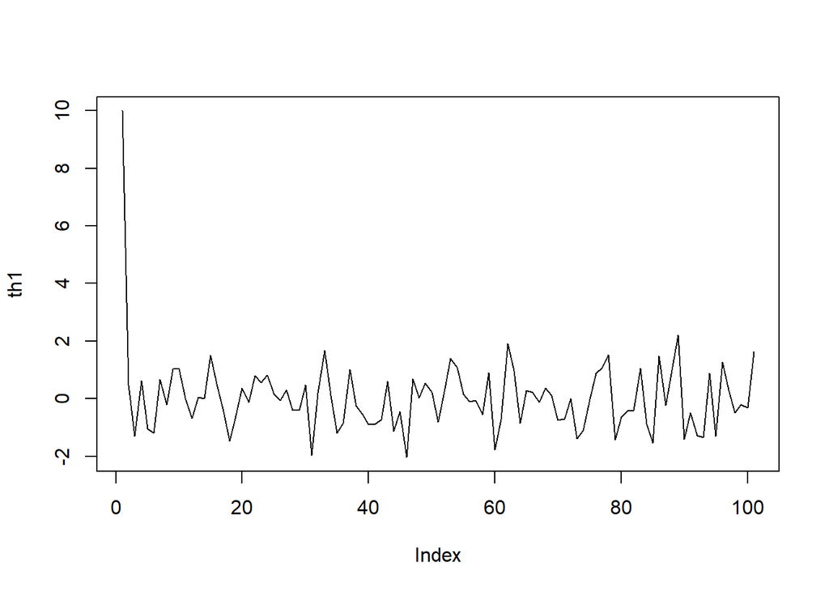

```r
# let's first define a function to conduct the sampling

markov <- function(first, phi, sigma, n){
  vec <- c(first)
  last <- first
  for(x in 1:n){
   last <- rnorm(1, mean=last*phi, sd=sigma)
   vec <- append(vec, last)
  }
  vec
}

th1 <- markov(10, 0, 1, 100)
th2 <- markov(10, 0.5, sqrt(3/4), 100)
th3 <- markov(10, sqrt(4/5), sqrt(1/5), 100)
th4 <- markov(10, 0.1, sqrt(0.99), 100)

plot(th1, type='l')
```

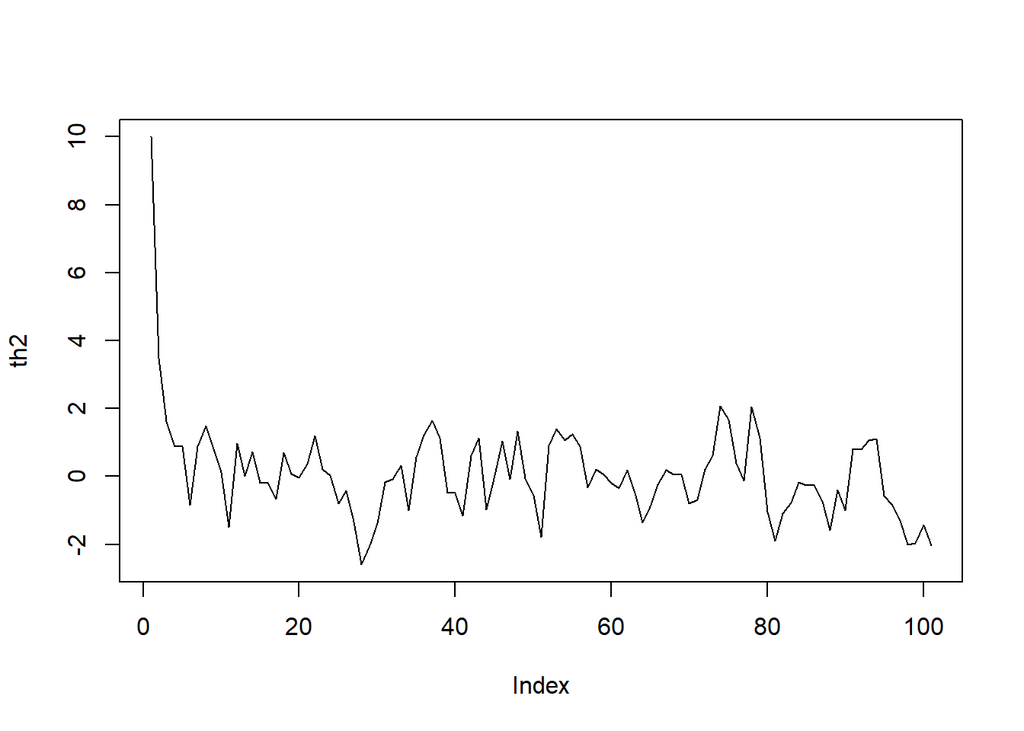

```r
plot(th2, type='l')
```

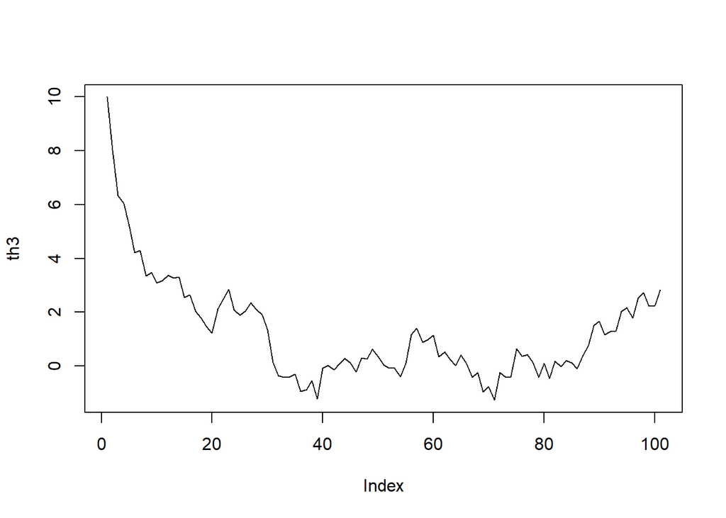

```r
plot(th3, type='l')
```

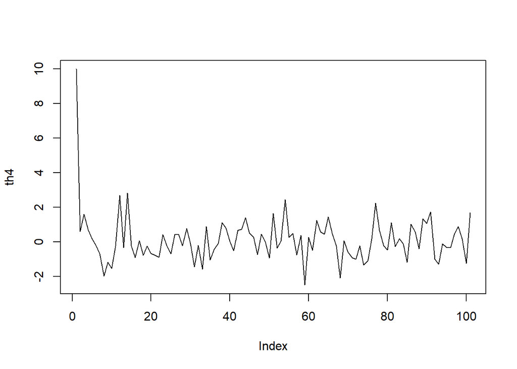

```r
plot(th4, type='l')
```

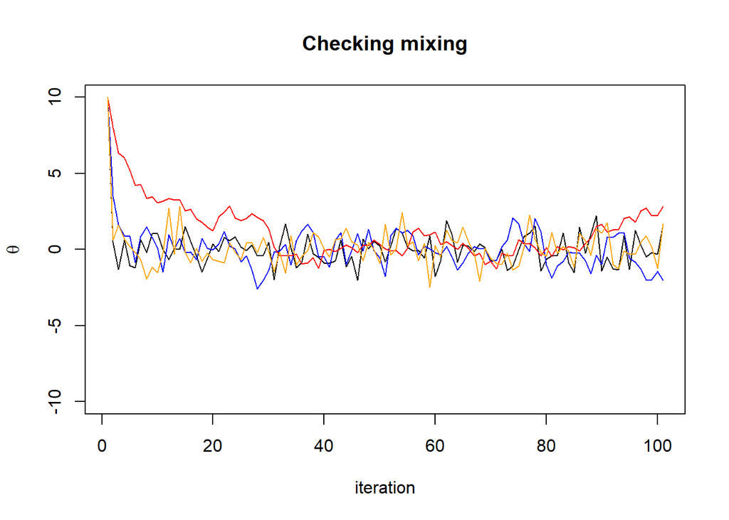

```r
plot(th1, type="l", xlab="iteration", ylab=expression(theta), main="Checking mixing", ylim=c(-10,10))
lines(th2, col="blue")
lines(th3, col="red")
lines(th4, col="orange")
```

```r
# Then we sample from the Markov chain with alternative phi and sigma values and draw them
```

The convergences clearly vary depending of the value of $\phi$, with a high $\phi$ causing slower convergence. All chains do eventually mix, but with higher $\sigma^2$ the noise from the variation is of course a bit higher.

**Result for task 4**

Choosing the parameter combination where $\sigma^2=0.2$ from the above table and running three Markov chains with initial values $C_1 = 10$, $C_2=-10$ and $C_3=5$. Finding a burn-in value at which the chains have converged according to the PSRF ($\hat{R}$) statistics. This is implemented in function in RStan. Note, $m=100$ samples might not be enough here.

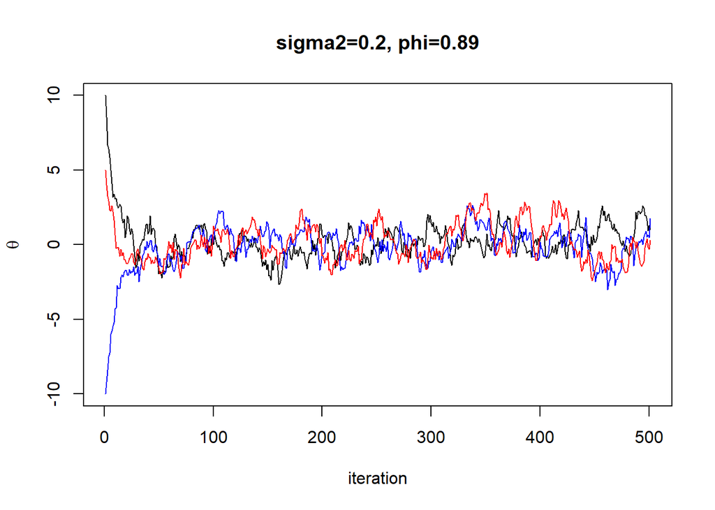

```r
# Define the sample size
m = 500

# sample from three independent Markov chains as instructed in the exercise
theta1 = markov(10, sqrt(4/5), sqrt(1/5), m)
theta2 = markov(-10, sqrt(4/5), sqrt(1/5), m)
theta3 = markov(5, sqrt(4/5), sqrt(1/5), m)

# examine the chains visually
plot(theta1, type="l", xlab="iteration", ylab=expression(theta), main=sprintf("sigma2=%.1f, phi=%.2f", 0.2,sqrt(4/5)), ylim=c(-10,10))
lines(theta2, col="blue")
lines(theta3, col="red")

# Check visually where the sample chains seem to have converged to the same stationary
# distribution

library(rstan)                       # First, load the necessary tool - that is Rhat function
```

```r
#?Rhat
THETA = rbind(theta1,theta2,theta3)  # Put the chains into list where each row is one Markov chain
Rhat(THETA)
```

```
## [1] 1.016621
```

```r
# if Rhat value is greater than 1.05 try to remove more samples from the beginning
# However, note that you may need to increase the sample size in order to get reliable estimate for PSRF
# Note also that the Rhat values change each time you rerun the Markov chains. Hence, even if with one
# realization the PSRF looked fine it might not be so in another even with same number of samples.
```